# Data Science Capstone - Word Prediction App

Thej

July 29, 2019

# Overview

The goal of the Data Science Capstone Project is to build a word prediction app deployed on [shinyapps.io](https://www.shinyapps.io/). These applications are very useful while typing on a mobile device. They also find use in predicting errors made by users while using search engines.

The following slides contain:

- Description of the algorithm used to make prediction
- How to Use the app and Comments on accuracy
- Conclusion and additional information

# Algorithm for prediction

- The prediction starts with cleaning the input
  - e.g., removing punctuation and making all cases lower
- An offline Ngram is built and optimized for memory and speed
  - Memory optimization for accuracy and speed led to 3s (from 30s) to load and <1s (from >10s) to predict for the same accuracy.
- Computing the [maximum likelihood estimation or MLE](https://lagunita.stanford.edu/c4x/Engineering/CS-224N/asset/slp4.pdf) based on the input and computed Ngrams (in this case 4gram to 2gram)
- Sorting and showing the output based on highest probability.

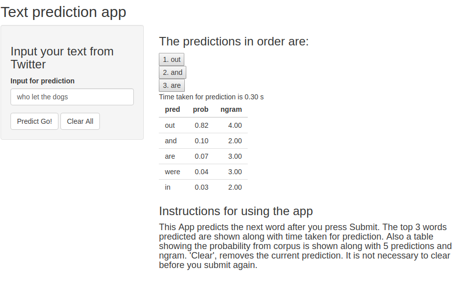

# How the app works and Accuracy

- Input is obtained and the `Predict` button is clicked to display output and `Clear` is used to remove the output.

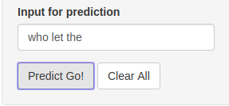

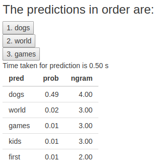

Input and Output

- Accuracy was tested to be 21% using [this benchmarking tool](https://github.com/hfoffani/dsci-benchmark) with entire corpus.
- Memory optimization for accuracy and speed led to 3s (from 30s) to load and <1s (from >10s) to predict for the same accuracy.

# References and Links

- The prediction app can be found here: https://agent18.shinyapps.io/NLP_DSCI/
- Maximum liklihood and algorithm can be found here: https://lagunita.stanford.edu/c4x/Engineering/CS-224N/asset/slp4.pdf
- A big inspiration was drawn from here: https://rpubs.com/pferriere/dscapreport